# Project: TMDB-Movies data Anallysis

- Introduction
- Data Wrangling
- Exploratory Data Analysis
- Conclusions

## Introduction

in this anallysis I used TMDB-Movies data set

the dataset contains information about 10,000 movies collected from The Movie Database (TMDb)

Qustions/

1-did the total Profits increased from the 1960 year until 2015 ?

2-what is the most successfull genres?

3-who is the most successfull director?

4-why does the director has the most number of successful movie ?

5- does having more revenue means the movie is more popular ?

6-what should you consider when making a movie?

```python
#import
import pandas as pd
from matplotlib import pyplot as plt
import numpy as np
import seaborn as sbs
%matplotlib inline
```

## Data Wrangling

### General Properties

```python
# Load the data set
df = pd.read_csv('tmdb-movies.csv')
```

```python
#check the data
df.head()
```

|  | id | imdb_id | popularity | budget | revenue | original_title | cast | homepage | director | tagline | ... | overview | runtime | genres | production_companies | release_date | vote_count | vote_average | release_year | budget_adj | revenue_adj |
| --- | --- | --- | --- | --- | --- | --- | --- | --- | --- | --- | --- | --- | --- | --- | --- | --- | --- | --- | --- | --- | --- |
| 0 | 135397 | tt0369610 | 32.985763 | 150000000 | 1513528810 | Jurassic World | Chris Pratt\|Bryce Dallas Howard\|Irrfan Khan\|Vi... | http://www.jurassicworld.com/ | Colin Trevorrow | The park is open. | ... | Twenty-two years after the events of Jurassic ... | 124 | Action\|Adventure\|Science Fiction\|Thriller | Universal Studios\|Amblin Entertainment\|Legenda... | 6/9/15 | 5562 | 6.5 | 2015 | 1.379999e+08 | 1.392446e+09 |
| 1 | 76341 | tt1392190 | 28.419936 | 150000000 | 378436354 | Mad Max: Fury Road | Tom Hardy\|Charlize Theron\|Hugh Keays-Byrne\|Nic... | http://www.madmaxmovie.com/ | George Miller | What a Lovely Day. | ... | An apocalyptic story set in the furthest reach... | 120 | Action\|Adventure\|Science Fiction\|Thriller | Village Roadshow Pictures\|Kennedy Miller Produ... | 5/13/15 | 6185 | 7.1 | 2015 | 1.379999e+08 | 3.481613e+08 |
| 2 | 262500 | tt2908446 | 13.112507 | 110000000 | 295238201 | Insurgent | Shailene Woodley\|Theo James\|Kate Winslet\|Ansel... | http://www.thedivergentseries.movie/#insurgent | Robert Schwentke | One Choice Can Destroy You | ... | Beatrice Prior must confront her inner demons ... | 119 | Adventure\|Science Fiction\|Thriller | Summit Entertainment\|Mandeville Films\|Red Wago... | 3/18/15 | 2480 | 6.3 | 2015 | 1.012000e+08 | 2.716190e+08 |
| 3 | 140607 | tt2488496 | 11.173104 | 200000000 | 2068178225 | Star Wars: The Force Awakens | Harrison Ford\|Mark Hamill\|Carrie Fisher\|Adam D... | http://www.starwars.com/films/star-wars-episod... | J.J. Abrams | Every generation has a story. | ... | Thirty years after defeating the Galactic Empi... | 136 | Action\|Adventure\|Science Fiction\|Fantasy | Lucasfilm\|Truenorth Productions\|Bad Robot | 12/15/15 | 5292 | 7.5 | 2015 | 1.839999e+08 | 1.902723e+09 |
| 4 | 168259 | tt2820852 | 9.335014 | 190000000 | 1506249360 | Furious 7 | Vin Diesel\|Paul Walker\|Jason Statham\|Michelle ... | http://www.furious7.com/ | James Wan | Vengeance Hits Home | ... | Deckard Shaw seeks revenge against Dominic Tor... | 137 | Action\|Crime\|Thriller | Universal Pictures\|Original Film\|Media Rights ... | 4/1/15 | 2947 | 7.3 | 2015 | 1.747999e+08 | 1.385749e+09 |

5 rows × 21 columns

```python
#check the info
df.info()
```

```
<class 'pandas.core.frame.DataFrame'>
RangeIndex: 10866 entries, 0 to 10865
Data columns (total 21 columns):
 #   Column                Non-Null Count  Dtype
---  ------                --------------  -----
 0   id                    10866 non-null  int64
 1   imdb_id               10856 non-null  object
 2   popularity            10866 non-null  float64
 3   budget                10866 non-null  int64
 4   revenue               10866 non-null  int64
 5   original_title        10866 non-null  object
 6   cast                  10790 non-null  object
 7   homepage              2936 non-null   object
 8   director              10822 non-null  object
 9   tagline               8042 non-null   object
 10  keywords              9373 non-null   object
 11  overview              10862 non-null  object
 12  runtime               10866 non-null  int64
 13  genres                10843 non-null  object
 14  production_companies  9836 non-null   object
 15  release_date          10866 non-null  object
 16  vote_count            10866 non-null  int64
 17  vote_average          10866 non-null  float64
 18  release_year          10866 non-null  int64
 19  budget_adj            10866 non-null  float64
 20  revenue_adj           10866 non-null  float64
dtypes: float64(4), int64(6), object(11)
memory usage: 1.7+ MB
```

```python
#check the shape
df.shape
```

```
(10866, 21)
```

```python
#describe
df.describe()
```

|  | id | popularity | budget | revenue | runtime | vote_count | vote_average | release_year | budget_adj | revenue_adj |
| --- | --- | --- | --- | --- | --- | --- | --- | --- | --- | --- |
| count | 10866.000000 | 10866.000000 | 1.086600e+04 | 1.086600e+04 | 10866.000000 | 10866.000000 | 10866.000000 | 10866.000000 | 1.086600e+04 | 1.086600e+04 |
| mean | 66064.177434 | 0.646441 | 1.462570e+07 | 3.982332e+07 | 102.070863 | 217.389748 | 5.974922 | 2001.322658 | 1.755104e+07 | 5.136436e+07 |
| std | 92130.136561 | 1.000185 | 3.091321e+07 | 1.170035e+08 | 31.381405 | 575.619058 | 0.935142 | 12.812941 | 3.430616e+07 | 1.446325e+08 |
| min | 5.000000 | 0.000065 | 0.000000e+00 | 0.000000e+00 | 0.000000 | 10.000000 | 1.500000 | 1960.000000 | 0.000000e+00 | 0.000000e+00 |
| 25% | 10596.250000 | 0.207583 | 0.000000e+00 | 0.000000e+00 | 90.000000 | 17.000000 | 5.400000 | 1995.000000 | 0.000000e+00 | 0.000000e+00 |
| 50% | 20669.000000 | 0.383856 | 0.000000e+00 | 0.000000e+00 | 99.000000 | 38.000000 | 6.000000 | 2006.000000 | 0.000000e+00 | 0.000000e+00 |
| 75% | 75610.000000 | 0.713817 | 1.500000e+07 | 2.400000e+07 | 111.000000 | 145.750000 | 6.600000 | 2011.000000 | 2.085325e+07 | 3.369710e+07 |
| max | 417859.000000 | 32.985763 | 4.250000e+08 | 2.781506e+09 | 900.000000 | 9767.000000 | 9.200000 | 2015.000000 | 4.250000e+08 | 2.827124e+09 |

### what I need to do to clean the data:

##### 1- I'll remove the columns I dont need to answer my quistions

##### 2-I'll check and remove the duplicate|

##### 3-I'll change the type of release_date to date type

### there is ZEROS in some coulmn which means there is no record for the value so I'll do the follwoing:

##### 4-I'll change the zeros to NAN in the runtime column

##### 5-I'll remove the rows with budget and revenue equals zero

##### 6-I'll change the format of budget and revenue form float to int

```python
#first I will delete the columns I won't need
df = df.drop(['imdb_id','budget_adj', 'revenue_adj',
              'homepage', 'keywords','tagline' ,'overview',
              'vote_count', 'vote_average'],1)
#check
df.head()
```

|  | id | popularity | budget | revenue | original_title | cast | director | runtime | genres | production_companies | release_date | release_year |
| --- | --- | --- | --- | --- | --- | --- | --- | --- | --- | --- | --- | --- |
| 0 | 135397 | 32.985763 | 150000000 | 1513528810 | Jurassic World | Chris Pratt\|Bryce Dallas Howard\|Irrfan Khan\|Vi... | Colin Trevorrow | 124 | Action\|Adventure\|Science Fiction\|Thriller | Universal Studios\|Amblin Entertainment\|Legenda... | 6/9/15 | 2015 |
| 1 | 76341 | 28.419936 | 150000000 | 378436354 | Mad Max: Fury Road | Tom Hardy\|Charlize Theron\|Hugh Keays-Byrne\|Nic... | George Miller | 120 | Action\|Adventure\|Science Fiction\|Thriller | Village Roadshow Pictures\|Kennedy Miller Produ... | 5/13/15 | 2015 |
| 2 | 262500 | 13.112507 | 110000000 | 295238201 | Insurgent | Shailene Woodley\|Theo James\|Kate Winslet\|Ansel... | Robert Schwentke | 119 | Adventure\|Science Fiction\|Thriller | Summit Entertainment\|Mandeville Films\|Red Wago... | 3/18/15 | 2015 |
| 3 | 140607 | 11.173104 | 200000000 | 2068178225 | Star Wars: The Force Awakens | Harrison Ford\|Mark Hamill\|Carrie Fisher\|Adam D... | J.J. Abrams | 136 | Action\|Adventure\|Science Fiction\|Fantasy | Lucasfilm\|Truenorth Productions\|Bad Robot | 12/15/15 | 2015 |
| 4 | 168259 | 9.335014 | 190000000 | 1506249360 | Furious 7 | Vin Diesel\|Paul Walker\|Jason Statham\|Michelle ... | James Wan | 137 | Action\|Crime\|Thriller | Universal Pictures\|Original Film\|Media Rights ... | 4/1/15 | 2015 |

```python
#Second I'll remove the duplicated rows
#check duplicate
sum(df.duplicated())
```

```
1
```

```python
#we only have 1 so I'll drop it
df.drop_duplicates(inplace=True)
#check if it got removed
sum(df.duplicated())
```

```
0
```

```python
#third I'll change the type of release_date to date type
df.release_date = pd.to_datetime(df['release_date'])
#check
df.head(2)
```

|  | id | popularity | budget | revenue | original_title | cast | director | runtime | genres | production_companies | release_date | release_year |
| --- | --- | --- | --- | --- | --- | --- | --- | --- | --- | --- | --- | --- |
| 0 | 135397 | 32.985763 | 150000000 | 1513528810 | Jurassic World | Chris Pratt\|Bryce Dallas Howard\|Irrfan Khan\|Vi... | Colin Trevorrow | 124 | Action\|Adventure\|Science Fiction\|Thriller | Universal Studios\|Amblin Entertainment\|Legenda... | 2015-06-09 | 2015 |
| 1 | 76341 | 28.419936 | 150000000 | 378436354 | Mad Max: Fury Road | Tom Hardy\|Charlize Theron\|Hugh Keays-Byrne\|Nic... | George Miller | 120 | Action\|Adventure\|Science Fiction\|Thriller | Village Roadshow Pictures\|Kennedy Miller Produ... | 2015-05-13 | 2015 |

```python
#forth I'll change the zeros to NAN in the runtime column
#first check the rows with runtime zero
df[df.runtime == 0].head()
```

|  | id | popularity | budget | revenue | original_title | cast | director | runtime | genres | production_companies | release_date | release_year |
| --- | --- | --- | --- | --- | --- | --- | --- | --- | --- | --- | --- | --- |
| 92 | 370687 | 1.876037 | 0 | 0 | Mythica: The Necromancer | Melanie Stone\|Adam Johnson\|Kevin Sorbo\|Nicola ... | A. Todd Smith | 0 | Fantasy\|Action\|Adventure | Arrowstorm Entertainment\|Camera 40 Productions... | 2015-12-19 | 2015 |
| 334 | 361931 | 0.357654 | 0 | 0 | Ronaldo | Cristiano Ronaldo | Anthony Wonke | 0 | Documentary | On The Corner Films\|We Came, We Saw, We Conque... | 2015-11-09 | 2015 |
| 410 | 339342 | 0.097514 | 0 | 0 | Anarchy Parlor | Robert LaSardo\|Jordan James Smith\|Sara Fabel\|T... | Kenny Gage\|Devon Downs | 0 | Horror | NaN | 2015-01-01 | 2015 |
| 445 | 353345 | 0.218528 | 0 | 0 | The Exorcism of Molly Hartley | Sarah Lind\|Devon Sawa\|Gina Holden\|Peter MacNei... | Steven R. Monroe | 0 | Horror | WT Canada Productions | 2015-10-09 | 2015 |
| 486 | 333653 | 0.176744 | 0 | 0 | If There Be Thorns | Heather Graham\|Jason Lewis\|Rachael Carpani\|Mas... | Nancy Savoca | 0 | TV Movie\|Drama | A+E Studios\|Jane Startz Productions | 2015-04-05 | 2015 |

```python
#replace the zeros with NAN
df['runtime'] =df['runtime'].replace(0, np.NAN)
#check again
df[df.runtime == 0]
```

|  | id | popularity | budget | revenue | original_title | cast | director | runtime | genres | production_companies | release_date | release_year |
| --- | --- | --- | --- | --- | --- | --- | --- | --- | --- | --- | --- | --- |

```python
#fifth I'll remove the rows with budget  and revenue equals zero
#first I'll replace the zeros with NAN
df[['budget','revenue']] = df[['budget','revenue']].replace(0, np.NAN)
```

```python
#then I'll remove the rows with NAN budget or revenue
df.dropna(subset = ['budget' ,'revenue'], inplace= True)
```

```python
#sixth I'll change the format of budget and revenue form float to int
df[['budget', 'revenue']]=df[['budget', 'revenue']].applymap(np.int64)
```

```python
#check
df.info()
```

```
<class 'pandas.core.frame.DataFrame'>
Int64Index: 3854 entries, 0 to 10848
Data columns (total 12 columns):
 #   Column                Non-Null Count  Dtype
---  ------                --------------  -----
 0   id                    3854 non-null   int64
 1   popularity            3854 non-null   float64
 2   budget                3854 non-null   int64
 3   revenue               3854 non-null   int64
 4   original_title        3854 non-null   object
 5   cast                  3850 non-null   object
 6   director              3853 non-null   object
 7   runtime               3854 non-null   float64
 8   genres                3854 non-null   object
 9   production_companies  3808 non-null   object
 10  release_date          3854 non-null   datetime64[ns]
 11  release_year          3854 non-null   int64
dtypes: datetime64[ns](1), float64(2), int64(4), object(5)
memory usage: 391.4+ KB
```

## Exploratory Data Analysis

```python
#check the data after cleaning
df.head(1)
```

|  | id | popularity | budget | revenue | original_title | cast | director | runtime | genres | production_companies | release_date | release_year |
| --- | --- | --- | --- | --- | --- | --- | --- | --- | --- | --- | --- | --- |
| 0 | 135397 | 32.985763 | 150000000 | 1513528810 | Jurassic World | Chris Pratt\|Bryce Dallas Howard\|Irrfan Khan\|Vi... | Colin Trevorrow | 124.0 | Action\|Adventure\|Science Fiction\|Thriller | Universal Studios\|Amblin Entertainment\|Legenda... | 2015-06-09 | 2015 |

```python
#I'll add a column for the total profits (revenue - budget)
df.insert(1,'total_profits',df['revenue'] - df['budget'])
#check
df.head(1)
```

|  | id | total_profits | popularity | budget | revenue | original_title | cast | director | runtime | genres | production_companies | release_date | release_year |
| --- | --- | --- | --- | --- | --- | --- | --- | --- | --- | --- | --- | --- | --- |
| 0 | 135397 | 1363528810 | 32.985763 | 150000000 | 1513528810 | Jurassic World | Chris Pratt\|Bryce Dallas Howard\|Irrfan Khan\|Vi... | Colin Trevorrow | 124.0 | Action\|Adventure\|Science Fiction\|Thriller | Universal Studios\|Amblin Entertainment\|Legenda... | 2015-06-09 | 2015 |

### Research Question 1 (did the total Profits increased from the year 1960 until 2015 ?)

```python
#first get the sum for every year
profits_year = df.groupby(['release_year']).sum()
#check
profits_year.head()
```

| release_year | id | total_profits | popularity | budget | revenue | runtime |
| --- | --- | --- | --- | --- | --- | --- |
| 1960 | 21729 | 108198052 | 6.622565 | 20806948 | 129005000 | 650.0 |
| 1961 | 110039 | 299083188 | 7.877177 | 38637000 | 337720188 | 1325.0 |
| 1962 | 27842 | 166879846 | 6.884396 | 39450000 | 206329846 | 989.0 |
| 1963 | 47815 | 115411882 | 6.243670 | 61115000 | 176526882 | 921.0 |
| 1964 | 29052 | 294678387 | 9.644529 | 33935161 | 328613548 | 857.0 |

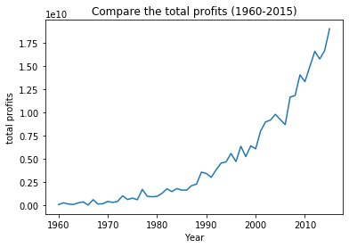

```python
#make the plot
plt.plot(profits_year.total_profits)
#put the labels
plt.title('Compare the total profits (1960-2015)')
plt.xlabel('Year')
plt.ylabel('total profits')
#show the plot
plt.show()
```

# Answer 1/ from the plot we see that the total profits have increased a lot since 1960

### Research Question 2 (which genres are most and least successfull)

```python
#first I need to choose which movies are consider successfull
#I'll take the movies that has total profits more than the average
su_movies = df[df['total_profits'] >= df.total_profits.mean()]

#I will make the index start from 1 and not from 0
su_movies.index = su_movies.index + 1
```

```python
#check
su_movies.head(3)
```

|  | id | total_profits | popularity | budget | revenue | original_title | cast | director | runtime | genres | production_companies | release_date | release_year |
| --- | --- | --- | --- | --- | --- | --- | --- | --- | --- | --- | --- | --- | --- |
| 1 | 135397 | 1363528810 | 32.985763 | 150000000 | 1513528810 | Jurassic World | Chris Pratt\|Bryce Dallas Howard\|Irrfan Khan\|Vi... | Colin Trevorrow | 124.0 | Action\|Adventure\|Science Fiction\|Thriller | Universal Studios\|Amblin Entertainment\|Legenda... | 2015-06-09 | 2015 |
| 2 | 76341 | 228436354 | 28.419936 | 150000000 | 378436354 | Mad Max: Fury Road | Tom Hardy\|Charlize Theron\|Hugh Keays-Byrne\|Nic... | George Miller | 120.0 | Action\|Adventure\|Science Fiction\|Thriller | Village Roadshow Pictures\|Kennedy Miller Produ... | 2015-05-13 | 2015 |
| 3 | 262500 | 185238201 | 13.112507 | 110000000 | 295238201 | Insurgent | Shailene Woodley\|Theo James\|Kate Winslet\|Ansel... | Robert Schwentke | 119.0 | Adventure\|Science Fiction\|Thriller | Summit Entertainment\|Mandeville Films\|Red Wago... | 2015-03-18 | 2015 |

```python
#check the shape
su_movies.shape
#we have 1066 rows now as successfull movies
```

```
(1066, 13)
```

```python
#I will make function to seprate the movies with more than one genres,actor..etc
def split(column):
    #I will make new column called sepData and seprate the Strings wtih |
    spData = su_movies[column].str.cat(sep = '|')
    #split the values
    spData = pd.Series(spData.split('|'))
    #arrange it and make it decending
    spData = spData.value_counts(ascending = False)
    #return value
    return spData
```

```python
#using the function
sep_su_movies = split('genres')
```

```python
#check
sep_su_movies.head()
```

```
Comedy       386
Action       385
Drama        368
Adventure    321
Thriller     312
dtype: int64
```

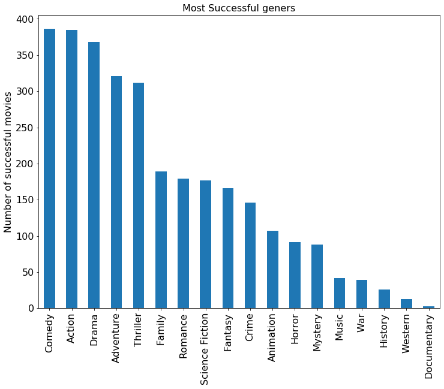

```python
#now that I have the number of every genre I will make the graph
#I'll make it bargraph and the fontsize will be 16
splt = sep_su_movies.plot(kind='bar' , fontsize =16);
#now I'll make the graph bigger
splt.figure.set_size_inches(12, 9)
#add labels
plt.title('Most Successful geners', fontsize =16)
plt.ylabel('Number of successful movies', fontsize =16)#show it
plt.show()
```

# Answer 2/ From the graph we see that the most successfull geners is Comdey, Action then Darma and the least is Documentary, Westren then History

### Research Question 3 (which director has the most successfull movies)

```python
#using the function
sDirector = split('director')
```

```python
#check
sDirector.head()
```

```
Steven Spielberg      22
Robert Zemeckis       12
Ridley Scott          10
Tim Burton             9
M. Night Shyamalan     8
dtype: int64
```

# Answer 3/ Steven Spielberg is the one with 22 successful movie

### Research Question 4 (what is the mean runtime, budget for successful movies)

```python
#average function
def calculateAvg(column):
    avg = su_movies[column].mean()
    return 'the average is: ' + str(avg)

#runtime
calculateAvg('runtime')
```

```
'the average is: 114.66697936210132'
```

```python
#budget
calculateAvg('budget')
```

```
'the average is: 66525485.24577861'
```

# Answer 4/ the mean runtime for the successful movies are 114.6

# and the mean budget for the successful movies are 66525485

### Research Question 5 (why Steven Spielberg does have the most successful movies ?)

```python
#first make new variable with successfull Steven Spielberg movies
sp_s = su_movies[su_movies.director == 'Steven Spielberg']
#check
sp_s.head(3)
```

|  | id | total_profits | popularity | budget | revenue | original_title | cast | director | runtime | genres | production_companies | release_date | release_year |
| --- | --- | --- | --- | --- | --- | --- | --- | --- | --- | --- | --- | --- | --- |
| 34 | 296098 | 122610473 | 3.648210 | 40000000 | 162610473 | Bridge of Spies | Tom Hanks\|Mark Rylance\|Amy Ryan\|Alan Alda\|Seba... | Steven Spielberg | 141.0 | Thriller\|Drama | DreamWorks SKG\|Amblin Entertainment\|Studio Bab... | 2015-10-15 | 2015 |
| 1335 | 840 | 283788635 | 1.104816 | 20000000 | 303788635 | Close Encounters of the Third Kind | Richard Dreyfuss\|FranÃ§ois Truffaut\|Teri Garr\|... | Steven Spielberg | 135.0 | Science Fiction\|Drama | Columbia Pictures Corporation\|EMI Films\|Julia ... | 1977-11-16 | 1977 |
| 2639 | 644 | 135926552 | 2.971372 | 100000000 | 235926552 | A.I. Artificial Intelligence | Haley Joel Osment\|Frances O'Connor\|Sam Robards... | Steven Spielberg | 146.0 | Drama\|Science Fiction\|Adventure | DreamWorks SKG\|Amblin Entertainment\|Stanley Ku... | 2001-06-29 | 2001 |

```python
#lets see the genres of his successful movies
#make split function
def splitSP(column):
    #I will make new column called sepData and seprate the Strings wtih |
    sepData = sp_s[column].str.cat(sep = '|')
    #split the values
    sepData = pd.Series(sepData.split('|'))
    #arrange it and make it decending
    sepData = sepData.value_counts(ascending = False)
    #return value
    return sepData

#use the function
splitSP('genres')
```

```
Adventure          12
Drama              10
Action              7
Science Fiction     7
Thriller            4
War                 4
Family              3
History             2
Comedy              2
Mystery             2
Fantasy             2
Animation           1
Crime               1
Horror              1
dtype: int64
```

## so most of his successfull movies are adventure and drama which is popular geners

```python
#compare the average budget for all successfull movies with Steven Spielberg movies
sp_MB = sp_s.budget.mean()
all_MB = su_movies.budget.mean()
#check the averges
print(sp_MB)
print(all_MB)
```

```
62568181.81818182
66525485.24577861
```

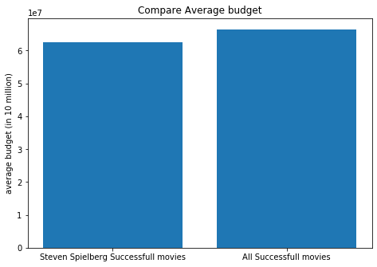

```python
#make chart
fig = plt.figure()
ax = fig.add_axes([0,0,1,1])
#name the bars
bDirectors = ['Steven Spielberg Successfull movies', 'All Successfull movies']
#put the values for bars
bAverage = [sp_MB,all_MB]
ax.bar(bDirectors,bAverage)
#add title
plt.title('Compare Average budget')
plt.ylabel('average budget (in 10 million)')
#show
plt.show()
```

## so steven's average budget for his movies is less than the average for all the movies but not very much.

```python
#now lets compare the mean runtime for his successfull movies with the mean runtime for all successfull movies
sp_RB = sp_s.runtime.mean()
all_RB = su_movies.runtime.mean()
#check the averges
print(sp_RB)
print(all_RB)
```

```
136.04545454545453
114.66697936210132
```

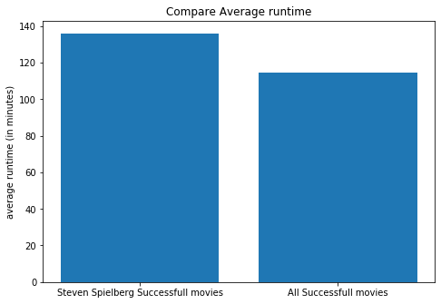

```python
#make chart
fig = plt.figure()
ax = fig.add_axes([0,0,1,1])
#name the bars
bDirectors = ['Steven Spielberg Successfull movies', 'All Successfull movies']
#put the values for bars
bAverage = [sp_RB,all_RB]
ax.bar(bDirectors,bAverage)
#add title
plt.title('Compare Average runtime')
plt.ylabel('average runtime (in minutes)')
#show
plt.show()
```